# Minor gland parts DE: effect of blocking on individual

Johan

12/11/2026

Compares the DESeq2 analysis of minor gland parts in `MinorAnalysis.Rmd` (design `~0 + Tissue`) with the same analysis blocking on individual (design `~individual + Tissue`, Tail_proximal as reference).

The individual is taken from the numeric suffix of the sample name (e.g. `SaCe_3` is individual 3). This is an assumption; check it against the sample metadata.

# Data (as in MinorAnalysis.Rmd)

```r
geneInfo <- read_csv(here("annotation", "Lsc.v1.0.3.geneInfo.csv.gz"))

# Gene filter: max TPM > 4 across all bulk samples
sampleInfo.QC.merged <- read_csv(here("MinorGland_paper", "data", "bulkRNA", "sampleInfo.QC.merged.csv.gz"))
bulk.data.merged <- read_csv(here("MinorGland_paper", "data", "bulkRNA", "All.samples.count.csv.gz")) |>
  rename(gene_id = "Geneid")
bulk.data.merged.QC <- bulk.data.merged[, c("gene_id", sampleInfo.QC.merged$sample)]

bulk.data.merged.QC |>
  pivot_longer(cols = -gene_id, names_to = "sample", values_to = "count") |>
  inner_join(geneInfo, by = "gene_id") |>
  mutate(normLengthCount = count / tx_len) |>
  group_by(sample) |>
  mutate(tpm = normLengthCount / sum(normLengthCount) * 1e6) |>
  group_by(gene_id) |>
  summarise(max_tpm = max(tpm)) |>
  filter(max_tpm > 4) |>
  inner_join(geneInfo, by = "gene_id") ->
  geneInfo.QC

# Proteomics-expressed genes
minorProteomics <- read_csv(here("MinorGland_paper", "data", "proteomics", "minor", "minorAmpullateEpxression.csv.gz"))
minorProteomics |>
  filter(Sample != "Mi_Dope_1") |>
  group_by(Part, geneName) |>
  summarise(numberOfSamples = n(),
            averageIntensity = sum(relativeIntensity) / numberOfSamples,
            .groups = "drop") |>
  group_by(geneName) |>
  summarise(max = max(averageIntensity)) |>
  filter(max > 0.0001) ->
  minorProteomics.expressed

geneInfo.QC.minor.prot <- inner_join(geneInfo.QC, minorProteomics.expressed, by = "geneName")

# Minor parts counts
MinorCounts <- read_tsv(here("MinorGland_paper", "data", "bulkRNA", "minorParts",
                             "minorParts.featureCount.reverse.txt.gz"), skip = 1) |>
  select(-6:-2) |>
  pivot_longer(names_to = "sample", values_to = "readCount", -Geneid) |>
  mutate(sample = gsub("/Aligned.sortedByCoord.out.bam", "", sample)) |>
  rename(gene_id = "Geneid") |>
  mutate(sample = gsub("PMI", "TaPr", sample),
         sample = gsub("DMI", "SaPr", sample),
         sample = gsub("BMI", "SaCe", sample),
         sample = gsub("CMI", "SaDi", sample),
         sample = gsub("CDMi", "SaDi_Du", sample))

TissueOrder <- c("Gland", "Tail_proximal", "Sac_proximal", "Sac_center", "Sac_distal", "Sac_distal_Duct")

MinorCounts |>
  distinct(sample) |>
  mutate(Tissue = case_when(
    grepl("SaDi_Du", sample) ~ "Sac_distal_Duct",
    grepl("SaDi", sample)    ~ "Sac_distal",
    grepl("SaPr", sample)    ~ "Sac_proximal",
    grepl("TaPr", sample)    ~ "Tail_proximal",
    TRUE                     ~ "Sac_center"),
    individual = paste0("ind", sub(".*_", "", sample))) |>
  mutate(Tissue = factor(Tissue, levels = TissueOrder)) |>
  arrange(Tissue) |>
  mutate(Tissue = as.character(Tissue)) ->
  MinorSampleInfo.QC

MinorSampleInfo.QC |> dplyr::count(Tissue, individual) |> pivot_wider(names_from = individual, values_from = n)
```

| Tissue | ind1 | ind2 | ind3 | ind4 | ind5 |
| --- | --- | --- | --- | --- | --- |
| Sac_center | 1 | 1 | 1 | 1 | 1 |
| Sac_distal | NA | NA | 1 | 1 | 1 |
| Sac_distal_Duct | 1 | 1 | NA | NA | NA |
| Sac_proximal | 1 | 1 | 1 | 1 | 1 |
| Tail_proximal | 1 | 1 | 1 | 1 | 1 |

All samples are included here, including the five removed by QC in `MinorAnalysis.Rmd` (SaCe_4, SaCe_1, SaPr_5, TaPr_1, SaPr_1).

Sac_distal_Duct exists only in individuals 1 and 2, and Sac_distal only in 3-5. Duct versus Sac_distal is therefore fully confounded with individual, so that contrast cannot be estimated with blocking. Only the analysis excluding the duct samples is compared below.

# DESeq2 with and without blocking

```r
MinorSampleInfo.QC |>
  filter(Tissue != "Sac_distal_Duct") |>
  mutate(individual = factor(individual)) ->
  si

dds.base <- getDEseq2Object(count.df = MinorCounts, md = si,
                            gi = geneInfo.QC.minor.prot, design = "Tissue")

dds.noblock <- dds.base
design(dds.noblock) <- ~ 0 + design

dds.block <- dds.base
# With an intercept and Tail_proximal as reference, each design coefficient is
# the part vs Tail_proximal contrast, adjusted for individual
dds.block$design <- relevel(dds.block$design, ref = "Tail_proximal")
design(dds.block) <- ~ individual + design

# Check the blocked design is full rank
qr(model.matrix(design(dds.block), colData(dds.block)))$rank == ncol(model.matrix(design(dds.block), colData(dds.block)))
```

```
## [1] TRUE
```

```r
dds.noblock <- DESeq(dds.noblock)
dds.block <- DESeq(dds.block)

resultsNames(dds.block)
```

```
## [1] "Intercept"
## [2] "individual_ind2_vs_ind1"
## [3] "individual_ind3_vs_ind1"
## [4] "individual_ind4_vs_ind1"
## [5] "individual_ind5_vs_ind1"
## [6] "design_Sac_center_vs_Tail_proximal"
## [7] "design_Sac_distal_vs_Tail_proximal"
## [8] "design_Sac_proximal_vs_Tail_proximal"
```

```r
contrasts.parts <- c(Sac_proximal = "designSac_proximal",
                     Sac_center   = "designSac_center",
                     Sac_distal   = "designSac_distal")

getParts <- function(dds, model) {
  imap(contrasts.parts, \(coefName, part) {
    res <- if (model == "no_block") {
      results(dds, contrast = list(c(coefName), c("designTail_proximal")), listValues = c(1, -1))
    } else {
      results(dds, name = paste0("design_", part, "_vs_Tail_proximal"))
    }
    res |>
      as.data.frame() |>
      rownames_to_column("gene_id") |>
      mutate(Tissue = part, model = model)
  }) |>
    bind_rows() |>
    select(gene_id, Tissue, model, baseMean, log2FoldChange, lfcSE, padj)
}

res.all <- bind_rows(getParts(dds.noblock, "no_block"),
                     getParts(dds.block, "block_individual")) |>
  filter(!is.na(padj))

res.wide <- res.all |>
  pivot_wider(names_from = model, values_from = c(baseMean, log2FoldChange, lfcSE, padj)) |>
  filter(!is.na(padj_no_block), !is.na(padj_block_individual)) |>
  inner_join(select(geneInfo, gene_id, geneName, geneNameProtein, signalP), by = "gene_id")
```

# Comparison

## Per-contrast significance (padj < 0.05, |log2FC| > log2(5))

```r
res.all |>
  mutate(sig = padj < 0.05 & abs(log2FoldChange) > log2(5)) |>
  group_by(model, Tissue) |>
  summarise(tested = n(), sig = sum(sig), .groups = "drop") |>
  pivot_wider(names_from = model, values_from = c(tested, sig))
```

| Tissue | tested_block_individual | tested_no_block | sig_block_individual | sig_no_block |
| --- | --- | --- | --- | --- |
| Sac_center | 1070 | 1021 | 54 | 44 |
| Sac_distal | 1070 | 1042 | 84 | 70 |
| Sac_proximal | 510 | 601 | 9 | 8 |

```r
res.wide |>
  mutate(sig_nb = padj_no_block < 0.05 & abs(log2FoldChange_no_block) > log2(5),
         sig_b = padj_block_individual < 0.05 & abs(log2FoldChange_block_individual) > log2(5)) |>
  group_by(Tissue) |>
  summarise(both = sum(sig_nb & sig_b),
            only_no_block = sum(sig_nb & !sig_b),
            only_block = sum(!sig_nb & sig_b),
            lfc_cor = cor(log2FoldChange_no_block, log2FoldChange_block_individual),
            median_se_ratio = median(lfcSE_block_individual / lfcSE_no_block))
```

| Tissue | both | only_no_block | only_block | lfc_cor | median_se_ratio |
| --- | --- | --- | --- | --- | --- |
| Sac_center | 41 | 3 | 7 | 0.9858043 | 0.6471960 |
| Sac_distal | 63 | 7 | 17 | 0.9784052 | 0.6804470 |
| Sac_proximal | 8 | 0 | 0 | 0.9799142 | 0.5667261 |

## Log2 fold changes

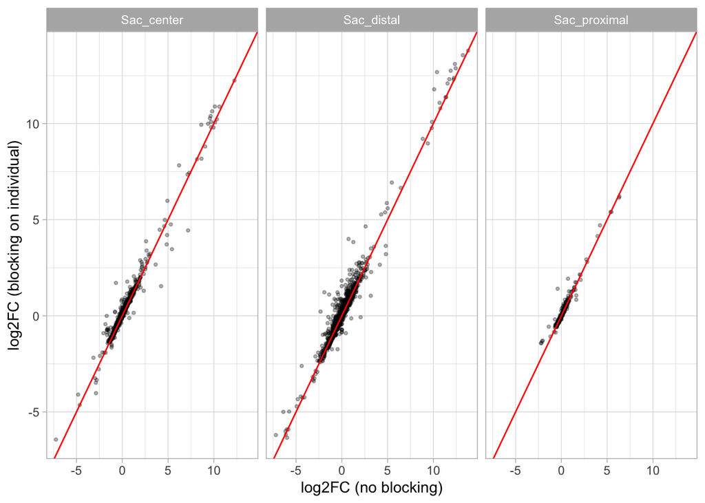

```r
ggplot(res.wide, aes(log2FoldChange_no_block, log2FoldChange_block_individual)) +
  geom_point(alpha = 0.3, size = 0.8) +
  geom_abline(color = "red") +
  facet_wrap(~Tissue) +
  theme_light() +
  labs(x = "log2FC (no blocking)", y = "log2FC (blocking on individual)")
```

## Adjusted p-values

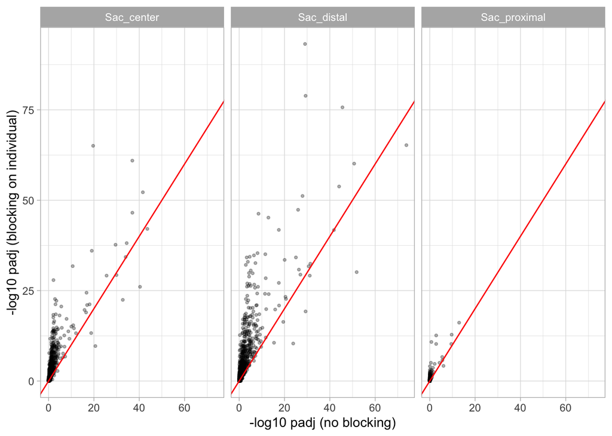

```r
ggplot(res.wide, aes(-log10(padj_no_block), -log10(padj_block_individual))) +
  geom_point(alpha = 0.3, size = 0.8) +
  geom_abline(color = "red") +
  facet_wrap(~Tissue) +
  theme_light() +
  labs(x = "-log10 padj (no blocking)", y = "-log10 padj (blocking on individual)")
```

## Pruned gene set used downstream (min padj < 0.05 and max |log2FC| > log2(5) across parts)

```r
prune <- function(df, model) {
  df |>
    filter(model == !!model) |>
    group_by(gene_id) |>
    summarise(minPadj = min(padj), maxFoldChange = max(abs(log2FoldChange))) |>
    filter(minPadj < 0.05, maxFoldChange > log2(5)) |>
    pull(gene_id)
}

genes.nb <- prune(res.all, "no_block")
genes.b <- prune(res.all, "block_individual")

tibble(set = c("no_block", "block_individual", "shared", "only_no_block", "only_block"),
       n = c(length(genes.nb), length(genes.b), length(intersect(genes.nb, genes.b)),
             length(setdiff(genes.nb, genes.b)), length(setdiff(genes.b, genes.nb))))
```

| set | n |
| --- | --- |
| no_block | 80 |
| block_individual | 101 |
| shared | 72 |
| only_no_block | 8 |
| only_block | 29 |

```r
geneInfo |>
  filter(gene_id %in% c(setdiff(genes.nb, genes.b), setdiff(genes.b, genes.nb))) |>
  mutate(set = if_else(gene_id %in% genes.nb, "only_no_block", "only_block")) |>
  select(set, gene_id, geneName, geneNameProtein, signalP)
```

| set | gene_id | geneName | geneNameProtein | signalP |
| --- | --- | --- | --- | --- |
| only_block | evm-000033F-processed-gene-24.21-GeneA | MaSp2c | MaSp2c | Yes |
| only_block | evm-000033F-processed-gene-27.15-GeneB | MaSp1b | MaSp1b | Yes |
| only_block | evm-000033F-processed-gene-27.15-GeneC | MaSp1c | MaSp1c | Yes |
| only_block | maker-000175F-exonerate_protein2genome-gene-8.3-GeneB | MaSp2f | MaSp2f | Yes |
| only_block | maker-000253F-exonerate_protein2genome-gene-5.2 | gstm1 | gstm1 | No |
| only_block | evm-000064F-processed-gene-15.2 | tmem68 | tmem68 | No |
| only_block | augustus_masked-000043F-processed-gene-9.2 | LASC004993 | LASC004993 | Yes |
| only_no_block | evm-000068F-processed-gene-21.17 | LASC007034 | LASC007034 | Yes |
| only_block | maker-000068F-exonerate_protein2genome-gene-32.14 | abhd12_2 | abhd12_2 | No |
| only_block | maker-000099F-exonerate_protein2genome-gene-1.2 | me1 | me1 | No |

[output cut: 27 more lines]

# Effect of the QC-removed samples, with and without blocking

Genes with a p-value but NA padj were removed by DESeq2 independent filtering. The filter threshold is chosen per contrast to maximise rejections, so a contrast with little signal gets a very high baseMean cutoff and loses many genes.

```r
badSamples <- c("SaCe_4", "SaCe_1", "SaPr_5", "TaPr_1", "SaPr_1")

fitModel <- function(drop_bad, block) {
  d <- dds.base
  if (drop_bad) d <- d[, !colnames(d) %in% badSamples]
  d$design <- droplevels(relevel(d$design, ref = "Tail_proximal"))
  d$individual <- droplevels(d$individual)
  design(d) <- if (block) ~ individual + design else ~ design
  DESeq(d, quiet = TRUE)
}

expand_grid(drop_bad = c(FALSE, TRUE), block = c(FALSE, TRUE)) |>
  pmap(\(drop_bad, block) {
    d <- fitModel(drop_bad, block)
    map(names(contrasts.parts), \(part) {
      nm <- paste0("design_", part, "_vs_Tail_proximal")
      rf <- results(d, name = nm)
      rn <- results(d, name = nm, independentFiltering = FALSE)
      tibble(drop_bad, block, part,
             filter_baseMean_cutoff = round(metadata(rf)$filterThreshold, 1),
             padj_NA_from_filtering = sum(is.na(rf$padj) & !is.na(rf$pvalue)),
             n_pvalue_below_0.05 = sum(rn$pvalue < 0.05, na.rm = TRUE),
             n_sig_filtered = sum(rf$padj < 0.05 & abs(rf$log2FoldChange) > log2(5), na.rm = TRUE),
             n_sig_unfiltered = sum(rn$padj < 0.05 & abs(rn$log2FoldChange) > log2(5), na.rm = TRUE))
    }) |> list_rbind()
  }) |>
  list_rbind()
```

| drop_bad | block | part | filter_baseMean_cutoff | padj_NA_from_filtering | n_pvalue_below_0.05 | n_sig_filtered | n_sig_unfiltered |
| --- | --- | --- | --- | --- | --- | --- | --- |
| FALSE | FALSE | Sac_proximal | 563.1 | 441 | 52 | 8 | 9 |
| FALSE | FALSE | Sac_center | 2.0 | 21 | 373 | 44 | 44 |
| FALSE | FALSE | Sac_distal | 0.0 | 0 | 454 | 70 | 70 |
| FALSE | TRUE | Sac_proximal | 842.5 | 560 | 201 | 9 | 9 |
| FALSE | TRUE | Sac_center | 0.0 | 0 | 567 | 54 | 54 |
| FALSE | TRUE | Sac_distal | 0.0 | 0 | 631 | 84 | 84 |
| TRUE | FALSE | Sac_proximal | 0.1 | 0 | 214 | 16 | 16 |
| TRUE | FALSE | Sac_center | 0.1 | 0 | 370 | 43 | 43 |
| TRUE | FALSE | Sac_distal | 0.1 | 0 | 572 | 95 | 95 |
| TRUE | TRUE | Sac_proximal | 7.7 | 42 | 274 | 16 | 17 |

[output cut: 2 more lines]